# Streamflow calculations using the dilution tracer method tutorial

Author

Lena Nelson

# Overview

Calculating streamflow can be difficult in small mountainous streams due to changing flows, rocky bed surfaces, and steep, fast flowing sections followed by pools. While there are a multitude of ways one can calculate streamflow, a standard procedure for calculating streamflow is the dilution tracer method.

This method involves injecting the stream with a known amount of salt and measuring the electrical conductivity. A sensor is placed in the stream and starts collecting the background conductivity of the stream. Then, a known amount of salt is dissolved in a bucket of the stream water and is dumped upstream of the sensor. As the water passes past the sensor, the electrical conductivity will increase and then drop back down to the baseline conductivity once all the salt has passed through. This is called the breakthrough curve. Discharge (Q), or streamflow, can then be calculated from the area under the curve and the mass of the salt.

However, the sensor reads the electrical conductivity in uS/cm. So in order to be able to use the electrical conductivity, the values need to be applied to a calibration curve to covert to concentration. From there, discharge can be calculated in g/L.

While there are textbook standards of a calibration curve, it is more accurate to create a calibration curve for your specific sensor.

This can be completed in the lab using DI water and dissolving small amounts of salt into the water.

While this process sounds relatively simple, when I was trying to calculate streamflow with data I collected, there was no standard code I could follow. Thus, from many trials and error I was able to:

- create a calibration curve
- calculate discharge

Therefore, the purpose of this tutorial is to walk through how to create a calibration curve from data collected in the lab. Then how to use the slope from the calibration curve and apply it to the calculations for calculating discharge.

The data used in this tutorial is the raw data collected when creating the calibration curve. For 5 different salt concentrations (0g, 0.5g, 1.0g, 1.5g, and 2g) the data the sensor collected was:

- the datetime
- electrical conductivity in uS/cm
- temperature

The stream dilution tracer data is an example dataset of the data the sensor collects which is:

- the datetime
- electrical conductivity in uS/cm
- temperature

All datasets will be read in from a .csv file. Metadata sheets from the calibration data and streamflow are also included which include the important times needed during the calculations.

# Calibration Curve

## Read in the data

First we need to install and load in the packages needed.

```r
# uncomment any of these that you don't already have installed
#install.packages("tidyverse")
#install.packages("hms")
#install.packages("pracma")
#install.packages("knitr")

# Load in the packages
library(tidyverse)
library(hms)
library(pracma)
library(knitr)
```

Now we can read in DI_intervals_test2.csv. The data collected in this csv was from DI water. The csv has the salt intervals, and is called test2 because it was the second test we conducted.

```r
# create a new dataframe by reading in the csv file DI_roomtemp_intervals_test2.csv
cal <- read_csv("DI_roomtemp_intervals_test2.csv", show_col_types = FALSE)

head(cal) # view the first rows of the dataset
```

```
# A tibble: 6 × 1
  `Plot Title: BridgerCreek_EC`
  <chr>
1 #,Date Time, GMT-06:00,Full Range, μS/cm (LGR S/N: 10778332, SEN S/N: 1077833…
2 1,03/24/26 11:32:34 AM,275.2,21.09,,,,,
3 2,03/24/26 11:32:35 AM,274.8,21.07,,,,,
4 3,03/24/26 11:32:36 AM,274.5,21.07,,,,,
5 4,03/24/26 11:32:37 AM,274.1,21.07,,,,,
6 5,03/24/26 11:32:38 AM,274.1,21.07,,,,,
```

```r
#re-read in the csv with better data organization
cal <- read_csv("DI_roomtemp_intervals_test2.csv",
                skip = 1,
                col_select = 2:4,
                show_col_types = FALSE)

head(cal) # view the first rows
```

```
# A tibble: 6 × 3
  `Date Time, GMT-06:00` Full Range, μS/cm (LGR S/N: 10…¹ Temp, °C (LGR S/N: 1…²
  <chr>                                             <dbl>                  <dbl>
1 03/24/26 11:32:34 AM                               275.                   21.1
2 03/24/26 11:32:35 AM                               275.                   21.1
3 03/24/26 11:32:36 AM                               274.                   21.1
4 03/24/26 11:32:37 AM                               274.                   21.1
5 03/24/26 11:32:38 AM                               274.                   21.1
6 03/24/26 11:32:39 AM                               274.                   21.0
# ℹ abbreviated names:
#   ¹`Full Range, μS/cm (LGR S/N: 10778332, SEN S/N: 10778332)`,
#   ²`Temp, °C (LGR S/N: 10778332, SEN S/N: 10778332)`
```

Okay that is better - but the column names are far too long and complicated. Let’s fix that! We want column one to be titled “time”, column 2 to be titled “conductivity_muS_cm”, and column 3 to be “temperature_C”. This gives informative titles that include the units of the measurements as well!

```r
#Clean up column names
colnames(cal)[1] <- "time"
colnames(cal)[2] <- "conductivity_muS_cm"
colnames(cal)[3] <- "temperature_C"

kable(head(cal)) #better way to see the columns
```

| time | conductivity_muS_cm | temperature_C |
| --- | --- | --- |
| 03/24/26 11:32:34 AM | 275.2 | 21.09 |
| 03/24/26 11:32:35 AM | 274.8 | 21.07 |
| 03/24/26 11:32:36 AM | 274.5 | 21.07 |
| 03/24/26 11:32:37 AM | 274.1 | 21.07 |
| 03/24/26 11:32:38 AM | 274.1 | 21.07 |
| 03/24/26 11:32:39 AM | 273.7 | 21.05 |

### Data exploration

Why don’t we go ahead and see what type of data we are working with using the `str()` function.

```r
str(cal)
```

```
spc_tbl_ [2,117 × 3] (S3: spec_tbl_df/tbl_df/tbl/data.frame)
 $ time               : chr [1:2117] "03/24/26 11:32:34 AM" "03/24/26 11:32:35 AM" "03/24/26 11:32:36 AM" "03/24/26 11:32:37 AM" ...
 $ conductivity_muS_cm: num [1:2117] 275 275 274 274 274 ...
 $ temperature_C      : num [1:2117] 21.1 21.1 21.1 21.1 21.1 ...
 - attr(*, "spec")=
  .. cols(
  ..   `#` = col_skip(),
  ..   `Date Time, GMT-06:00` = col_character(),
  ..   `Full Range, μS/cm (LGR S/N: 10778332, SEN S/N: 10778332)` = col_double(),
  ..   `Temp, °C (LGR S/N: 10778332, SEN S/N: 10778332)` = col_double(),
  ..   `Coupler Detached (LGR S/N: 10778332)` = col_skip(),
  ..   `Coupler Attached (LGR S/N: 10778332)` = col_skip(),
  ..   `Host Connected (LGR S/N: 10778332)` = col_skip(),
  ..   `Stopped (LGR S/N: 10778332)` = col_skip(),
  ..   `End Of File (LGR S/N: 10778332)` = col_skip()
  .. )
 - attr(*, "problems")=<externalptr>
```

From this we can see that our time column is actually a character when we want it to be a time. Let’s fix that using the `as.POSIXct()`. Then let’s extract the time stamp using `as_hms()` since we just need to work with hours, minutes, and seconds.

```r
# convert time column to datetime
cal$time <- as.POSIXct(cal$time, format = "%m/%d/%y %I:%M:%S %p")
cal$time_only <- as_hms(cal$time)
```

Why don’t we run some basic summary statistics to get a general idea about our data:

```r
summary(cal)
```

```
      time                     conductivity_muS_cm temperature_C
 Min.   :2026-03-24 11:32:34   Min.   :  3.7       Min.   :20.71
 1st Qu.:2026-03-24 11:41:23   1st Qu.: 41.1       1st Qu.:26.03
 Median :2026-03-24 11:50:12   Median :414.2       Median :26.41
 Mean   :2026-03-24 11:50:12   Mean   :386.9       Mean   :26.31
 3rd Qu.:2026-03-24 11:59:01   3rd Qu.:669.0       3rd Qu.:26.81
 Max.   :2026-03-24 12:07:50   Max.   :884.6       Max.   :27.61
   time_only
 Min.   :11:32:34
 1st Qu.:11:41:23
 Median :11:50:12
 Mean   :11:50:12
 3rd Qu.:11:59:01
 Max.   :12:07:50
```

The time ranges from 11:32:34 to 12:07:50. Conductivity values range from 3.7 to 884.6. Temperature values from from 20.71 to 27.61 C.

Let’s check that our timestamps are correct before we move on.

```r
str(cal)
```

```
spc_tbl_ [2,117 × 4] (S3: spec_tbl_df/tbl_df/tbl/data.frame)
 $ time               : POSIXct[1:2117], format: "2026-03-24 11:32:34" "2026-03-24 11:32:35" ...
 $ conductivity_muS_cm: num [1:2117] 275 275 274 274 274 ...
 $ temperature_C      : num [1:2117] 21.1 21.1 21.1 21.1 21.1 ...
 $ time_only          : 'hms' num [1:2117] 11:32:34 11:32:35 11:32:36 11:32:37 ...
  ..- attr(*, "units")= chr "secs"
 - attr(*, "spec")=
  .. cols(
  ..   `#` = col_skip(),
  ..   `Date Time, GMT-06:00` = col_character(),
  ..   `Full Range, μS/cm (LGR S/N: 10778332, SEN S/N: 10778332)` = col_double(),
  ..   `Temp, °C (LGR S/N: 10778332, SEN S/N: 10778332)` = col_double(),
  ..   `Coupler Detached (LGR S/N: 10778332)` = col_skip(),
  ..   `Coupler Attached (LGR S/N: 10778332)` = col_skip(),
  ..   `Host Connected (LGR S/N: 10778332)` = col_skip(),
  ..   `Stopped (LGR S/N: 10778332)` = col_skip(),
  ..   `End Of File (LGR S/N: 10778332)` = col_skip()
  .. )
 - attr(*, "problems")=<externalptr>
```

Great! Looks like we are good to go.

## Finding average conductivity

To create our calibration curve, we need to find the average conductivity from our 5 salt samples:

- 0 g
- 0.5 g
- 1.0 g
- 1.5 g
- 2.0 g

For reference, the sensor was placed in a bucket with 5 L of DI water. At each salt increase, the sensor sat in the water for 5 minutes. The data is recorded in the “20260324_cal_metadata.docx” file. The 5 minutes was a buffer, so we will take the middle 3 minutes of the time range and take the average of that. For simplicity in this tutorial, I will provide the time ranges for each salt interval to use:

- 11:34 to 11:38
- 11:43 to 11:46
- 11:50 to 11:53
- 11:56 to 11:59
- 12:02 to 12:05

Now that we have the times, let’s calculate average conductivity for each interval. To do this, let’s define a new dataframe called cal_subset. We will use just the time_only variable and find the data that is greater than or equal to the lower time bound, and less than or equal to the upper time bound. We will then create a new dataframe called avg_xxxg that takes the mean conductivity_muS_cm in the cal_subet dataframe. We repeat this for each interval time and salt mass.

```r
#calculate average conductivity from 11:34 to 11:38
# this is 0 g added salt
cal_subset <- cal[
  cal$time_only >= as_hms("11:34:00") &
  cal$time_only <= as_hms("11:38:00"), ]
avg_0g <- mean(cal_subset$conductivity_muS_cm, na.rm = TRUE)
```

```r
#repeat for 11:43 to 11:46
#this is 0.5 g of added salt
cal_subset <- cal[
  cal$time_only >= as_hms("11:43:00") &
  cal$time_only <= as_hms("11:46:00"), ]
avg_500mg <- mean(cal_subset$conductivity_muS_cm, na.rm = TRUE)
```

```r
#repeat for 11:50 to 11:53
#this is 1.0 g of added salt
cal_subset <- cal[
  cal$time_only >= as_hms("11:50:00") &
  cal$time_only <= as_hms("11:53:00"), ]
avg_1000mg <- mean(cal_subset$conductivity_muS_cm, na.rm = TRUE)
```

```r
#repeat for 11:56 to 11:59
#this is 1.5 g of added salt
cal_subset <- cal[
  cal$time_only >= as_hms("11:56:00") &
  cal$time_only <= as_hms("11:59:00"), ]
avg_1500mg <- mean(cal_subset$conductivity_muS_cm, na.rm = TRUE)
```

```r
# repeat for 12:02 to 12:05
#this is 2.0 g of added salt
cal_subset <- cal[
  cal$time_only >= as_hms("12:02:00") &
  cal$time_only <= as_hms("12:05:00"), ]
avg_2000mg <- mean(cal_subset$conductivity_muS_cm, na.rm = TRUE)
```

Let’s print these values using the `print()` function so we can visually see all the values.

```r
print(c(avg_0g, avg_500mg, avg_1000mg, avg_1500mg, avg_2000mg))
```

```
[1]  11.79917 235.99337 456.35580 669.19116 875.07348
```

Great now we have the average conductivity for each interval. Let’s plot those values!

## Create calibration curve

First, let’s create a list of the salt values in milligrams. We will also create a list of the conductivity values in the same order as the salt values using the values stored in the data frames we created for each interval. Then we will just use the `plot()` function since we are working with two datasets that each contain only one variable. We will add axis titles using `xlab` and `ylab` and a main title using `main`.

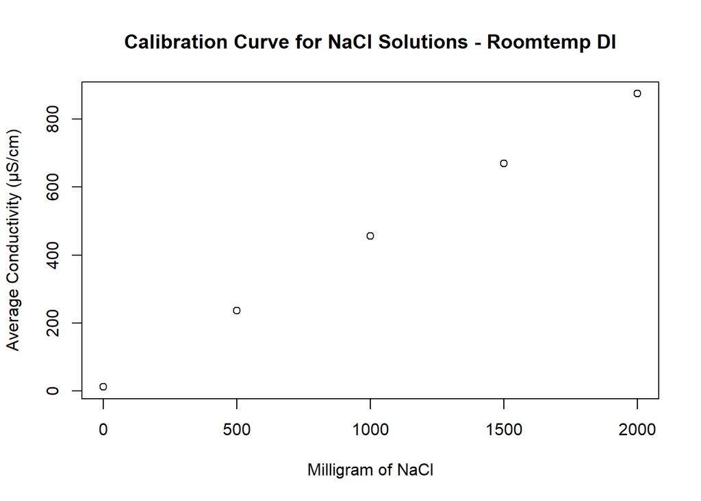

```r
milligram_values <- c(0, 500, 1000, 1500, 2000) #put the salt values into a list
conductivity_values <- c(avg_0g, avg_500mg, avg_1000mg, avg_1500mg, avg_2000mg) #use the average conductivity values we generated earlier and put them into a list
plot(milligram_values, conductivity_values, #use plot() since we are just working with basic x and y variables that are not in the same dataframe
     xlab = "Milligram of NaCl",
     ylab = "Average Conductivity (µS/cm)",
     main = "Calibration Curve for NaCl Solutions - Roomtemp DI")
```

From first glance we can see that the points are somewhat linear - that’s great! But let’s fit a linear regression line to the plot to figure out the slope and intercept, which are needed later in the discharge calculations.

Create a new dataframe called model (this is because we are using the linear regression model). Then use `lm()` which applies the linear regression model to the data. `lm()` is set up as response ~ predictor, so we will set it up as conductivity_values ~ milligram_values since the conductivity values are dependent on the milligram values. To visually see the line we use `abline()` which adds a straight line through the current plot and color the line red.

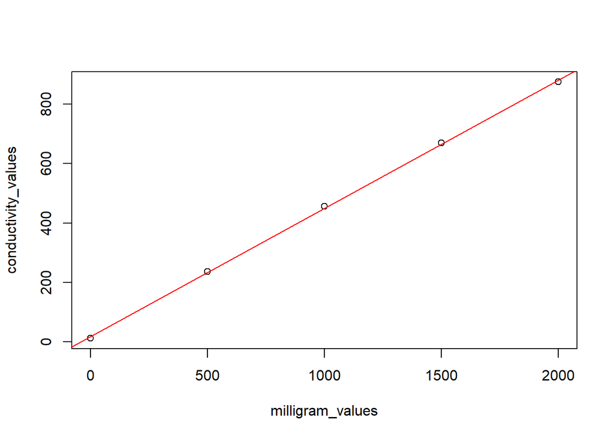

```r
#Linear regression for data
plot(milligram_values, conductivity_values)
model <- lm(conductivity_values ~ milligram_values)
abline(model, col = "red")
```

Now, let’s extract the slope and intercept value from the model. How we do this is using the `coef()` function. Let’s see what happens when we run that.

```r
coef(model)
```

```
     (Intercept) milligram_values
      17.7333142        0.4319493
```

Okay we can see that it gave us the intercept and also the slope, but the slope is recorded under “milligram_values” which is not very intuitive. Instead, let’s extract both of those values one at a time and assign them to a dataframe.

```r
#pull out slope and intercept
slope <- coef(model)[2] #pulls out just slope
intercept <- coef(model)[1] #pulls out just intercept
```

We can also see the full output of the model using `summary()`. Let’s give that a try.

```r
summary(model)
```

```
Call:
lm(formula = conductivity_values ~ milligram_values)

Residuals:
     1      2      3      4      5
-5.934  2.285  6.673  3.534 -6.558

Coefficients:
                  Estimate Std. Error t value Pr(>|t|)
(Intercept)      17.733314   5.300378   3.346   0.0442 *
milligram_values  0.431949   0.004328  99.809 2.22e-06 ***
---
Signif. codes:  0 '***' 0.001 '**' 0.01 '*' 0.05 '.' 0.1 ' ' 1

Residual standard error: 6.843 on 3 degrees of freedom
Multiple R-squared:  0.9997,    Adjusted R-squared:  0.9996
F-statistic:  9962 on 1 and 3 DF,  p-value: 2.217e-06
```

Now let’s print the results so we can see what the values are.

```r
print(slope)
```

```
milligram_values
       0.4319493
```

```r
print(intercept)
```

```
(Intercept)
   17.73331
```

Well those labels don’t make a lot of sense. Let’s try again using `cat` which allows you concatenate and print. To use the function, we are first putting the text we want into the “quote” followed by the dataframe we are using, and then we use `"\n"` to create a new line so everything isn’t squished!

If you want to know more, type `?cat` into the console.

```r
#display slope and intercept
cat("Slope:", slope, "\n")
```

```
Slope: 0.4319493
```

```r
cat("Intercept:", intercept, "\n")
```

```
Intercept: 17.73331
```

We have now successfully created a calibration curve and have extracted the slope and intercept values that we will apply in the next section: discharge calculations.

# Discharge Calculations

## Read in the data

Let’s start by reading in the raw data in the same way we did for the calibration curve data (skip the first row, select only columns 2:4, and rename the columns to be more user friendly). The csv file is called “BC_EC_20260130.csv”. The data was collected on January 30th, 2026.

```r
# Read in the data
ec_data = read_csv("BC_EC_20260130.csv",
                   show_col_types = FALSE,
                   skip = 1,
                   col_select = 2:4)

# rename columns
colnames(ec_data)[1] <- "time"
colnames(ec_data)[2] <- "conductivity_muS_cm"
colnames(ec_data)[3] <- "temperature_C"
```

Again, let’s convert the time column to a datetime. We also just need the time again, so let’s create a new column called “time_only”.

```r
# convert time column to datetime
ec_data$time <- as.POSIXct(ec_data$time, format = "%m/%d/%y %I:%M:%S %p")
ec_data$time_only <- as_hms(ec_data$time)
```

Check to make sure it looks correct.

```r
kable(head(ec_data))
```

| time | conductivity_muS_cm | temperature_C | time_only |
| --- | --- | --- | --- |
| 2026-01-30 10:50:00 | 7.1 | 19.72 | 10:50:00 |
| 2026-01-30 10:50:01 | 7.1 | 19.72 | 10:50:01 |
| 2026-01-30 10:50:02 | 7.1 | 19.72 | 10:50:02 |
| 2026-01-30 10:50:03 | 7.1 | 19.73 | 10:50:03 |
| 2026-01-30 10:50:04 | 7.1 | 19.73 | 10:50:04 |
| 2026-01-30 10:50:05 | 7.1 | 19.73 | 10:50:05 |

Awesome!

Now we need to define a couple variables that we can get from the metadata sheet. The metadata file is called “20260130_metadata.xlsx”. We will need:

- mass (in grams)
- probe_in_time (the time the sensor was placed into the stream in hh:mm:ss)
- inj_time (the time the salt was injected into the stream in hh:mm:ss)
- end_time (the time the sensor was taken out of the water in hh:mm:ss)

```r
# Information from the metadata sheet
mass <- 600

inj_time <- "11:57:00"

end_time <- "12:25:00"

probe_in_time <- "11:45:00"
```

Alright, let’s do an initial plot to visualize the data using ggplot.

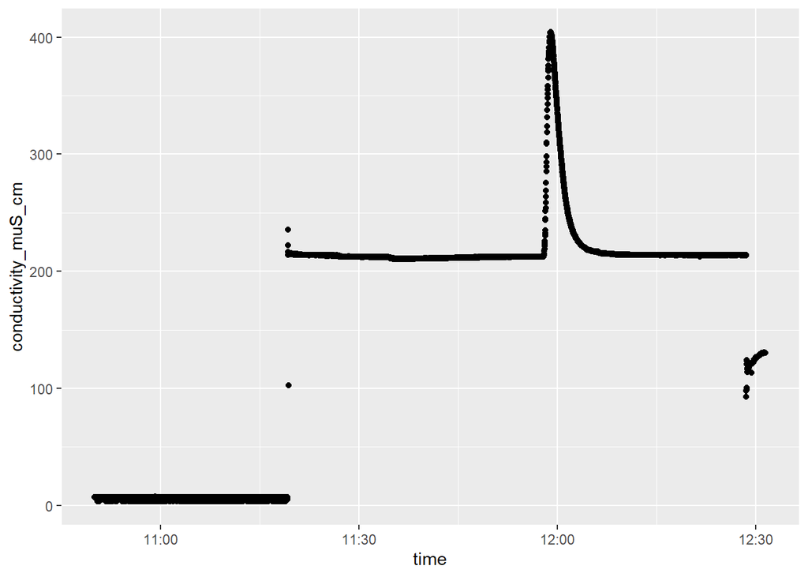

```r
# plot to visualize data
ec_data |>
  ggplot(aes(x = time, y = conductivity_muS_cm)) +
  geom_point()
```

Cool! We can see the electrical conductivity before we put the sensor in, those are the dots with almost zero conductivity. Then we can see once we put the sensor in because the conductivity jumps up. But the most important thing is that we can see the breakthrough curve! After the breakthrough curve, we see that the electrical conductivity goes back to the baseline of the water. That is a good sign that everything worked correctly, phew!

## Injection window

Now we can filter the data to just the injection window, which is the time between when we put the salt in the stream and when we took the sensor out of the stream. We make this really easy by using the times we already defined earlier.

```r
# filter to just injection window
injection_window <- ec_data |>
  filter(
    time_only > as_hms(inj_time) &
      time_only < as_hms(end_time)
  )
```

To make sure we did that correctly, let’s do another very basic visualization plot.

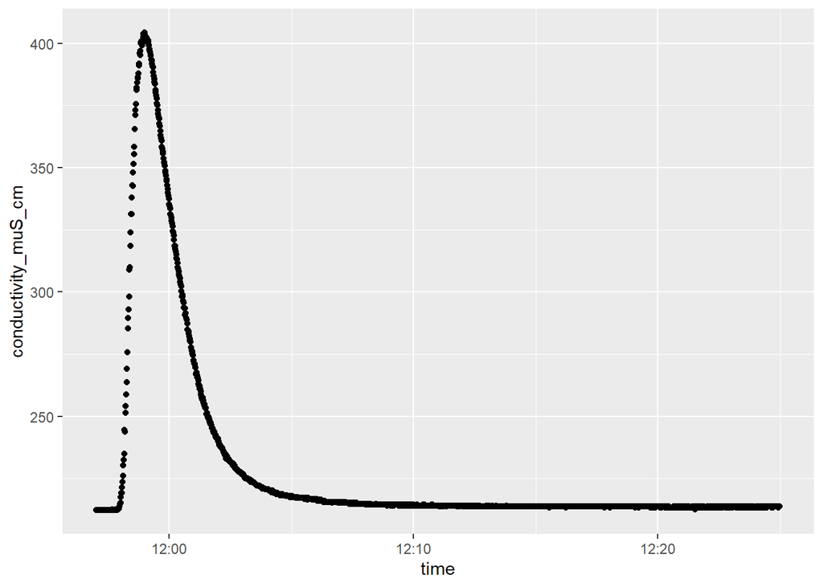

```r
# plot injection window
injection_window |>
  ggplot(aes(x = time, y = conductivity_muS_cm)) +
  geom_point()
```

Great - we can see that just the breakthrough curve plus the tail is included. It is important to include the entire tail because some residual salt is still passing through. If you take the sensor out too early it can affect your discharge values.

## Background conductivity

If you look at the graph, you can see that the values start between 200 and 225 uS/cm. While those are the actual values of the stream, we want to correct for the background conductivity, or the natural electrical conductivity of the stream on its own.

To do this, we will filter from when we put the sensor in the water to when we put the salt in.

```r
# background correct breakthrough curve
background_window <- ec_data |>
  filter(
    time_only > as_hms(probe_in_time) &
      time_only < as_hms(inj_time)
  )
```

Now that we have a new dataframe with the background conductivity, we need to find the average over that time period.

```r
# average background conductivity
avg_background <- mean(background_window$conductivity_muS_cm, na.rm = TRUE)

print(avg_background)
```

```
[1] 211.9864
```

Cool - the background conductivity of the stream is 211.99.

We now need to calculate the electrical conductivity corrected to the background conductivity. To do so, we will subtract the avg_background from conductivity_muS_cm and create a new column called ec_excess. We don’t want those values to be negative, so let’s do a simple ifelse statement where if the value is less than 0, replace it with 0. If it isn’t keep the original value.

```r
# calculate EC by subtracting the background conductivity
injection_window <- injection_window |>
  mutate(ec_excess = conductivity_muS_cm - avg_background) |> # create new column called ec_excess
  mutate(ec_excess = ifelse(ec_excess < 0, 0, ec_excess)) # this avoids any negative values
```

To integrate later, we will need a column of just seconds (1, 2, 3, etc.) for the injection_window dataframe. Let’s do that now while we are already making new columns.

```r
#create a column of seconds
injection_window <- injection_window |>
  mutate(time_s = row_number())
```

Let’s check to make sure that all worked correctly.

```r
kable(head(injection_window))
```

| time | conductivity_muS_cm | temperature_C | time_only | ec_excess | time_s |
| --- | --- | --- | --- | --- | --- |
| 2026-01-30 11:57:01 | 212.2 | 0.61 | 11:57:01 | 0.21363 | 1 |
| 2026-01-30 11:57:02 | 212.2 | 0.60 | 11:57:02 | 0.21363 | 2 |
| 2026-01-30 11:57:03 | 212.2 | 0.61 | 11:57:03 | 0.21363 | 3 |
| 2026-01-30 11:57:04 | 212.2 | 0.61 | 11:57:04 | 0.21363 | 4 |
| 2026-01-30 11:57:05 | 212.2 | 0.61 | 11:57:05 | 0.21363 | 5 |
| 2026-01-30 11:57:06 | 212.2 | 0.61 | 11:57:06 | 0.21363 | 6 |

Great. Now that we created a new column of ec_excess and seconds, let’s plot it to make sure it still looks correct. It should look the exact same as earlier, but this time the EC values start at 0 and the x-axis should be in seconds starting at 0.

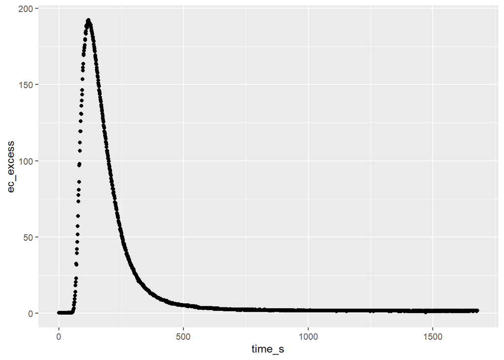

```r
# plot to see it corrected vs seconds
injection_window |>
  ggplot(aes(x = time_s, y = ec_excess)) +
  geom_point()
```

Looks good!

## Convert from conductivity to concentration

Now we are ready to apply our values from the calibration curve to calculate the concentration from the conductivity.

- where y = EC
- where x = NaCl concentration in g/5L

0.4319 is the slope

But since we did our calibrations in grams per 5 liters we need to convert from g/5L to g/L. You do this by dividing by 5000:

To calculate the concentration, we need to apply this formula to our ec_excess column. We will create a new column called NaCl from this calculation. We will also replace any negative values with 0, same as before.

```r
#calculate concentration
injection_window <- injection_window |>
  mutate(NaCl = (ec_excess - intercept) / slope / 5000)

#replace any negative values with 0
injection_window <- injection_window |>
  mutate(NaCl = ifelse(NaCl < 0, 0, NaCl))
```

## Integration

Now the fun part - integration.

This is the standard trapezoid integration code set-up for the dilution gauging method. I followed steps outlined by Tim Covino, Professor at Montana State, in this code: https://tpcovino.github.io/Git_home/hydrology/3_dilution_gauging/R/dilution_5_3_22.html

```r
# trapezoid integration
injection_window <- injection_window |>
  mutate(
    IntC_s1 = NaCl + lag(NaCl, default = 0),  # sum of consecutive points
    IntC = cumsum(IntC_s1 * 0.5 * 1),     # trapezoid integration (g/L * time)
    recovery = IntC / max(IntC)     # fraction of total tracer recovered
  )
```

The hard part is done, now all we need to do is calculate the streamflow following the very basic formulation where:

streamflow (Q) = mass of salt / (concentration * time)

Q = g / (g/L * s)

Q = L/s

```r
Q <- mass / max(injection_window$IntC)

print(Q)
```

```
[1] 62.87469
```

And that is it!

# Summary

We followed steps to calculate streamflow using the dilution tracer method. We first read in and cleaned data for the calibration curve. Through the processing steps we were able to calculate the slope (0.432) and intercept (17.7) to be used in the discharge calculations.

We then read in and cleaned data for the dilution calculations. We filtered the data for the injection window, calculated the background conductivity, found excess EC, converted conductivity to concentration, and integrated the breakthrough curve. We then found discharge by dividing the integration from the mass.

Through these steps, we found that the discharge for this data is 62.9 L/s. This is equivalent to 2.2 cubic feet per second, or 997 gallons per minute.

# Full code

```r
# load in the libraries
library(tidyverse)
library(hms)
library(pracma)
library(knitr)

# Calibration curve

# read in the calibration curve data
cal <- read_csv("DI_roomtemp_intervals_test2.csv",
                skip = 1,
                col_select = 2:4,
                show_col_types = FALSE)

#Clean up column names
colnames(cal)[1] <- "time"
colnames(cal)[2] <- "conductivity_muS_cm"
colnames(cal)[3] <- "temperature_C"

# convert time column to datetime
cal$time <- as.POSIXct(cal$time, format = "%m/%d/%y %I:%M:%S %p")
cal$time_only <- as_hms(cal$time)

#calculate average conductivity from 11:34 to 11:38
# this is 0 g added salt
cal_subset <- cal[
  cal$time_only >= as_hms("11:34:00") &
  cal$time_only <= as_hms("11:38:00"), ]
avg_0g <- mean(cal_subset$conductivity_muS_cm, na.rm = TRUE)

#repeat for 11:43 to 11:46
#this is 0.5 g of added salt
cal_subset <- cal[
  cal$time_only >= as_hms("11:43:00") &
  cal$time_only <= as_hms("11:46:00"), ]
avg_500mg <- mean(cal_subset$conductivity_muS_cm, na.rm = TRUE)

#repeat for 11:50 to 11:53
#this is 1.0 g of added salt
cal_subset <- cal[
  cal$time_only >= as_hms("11:50:00") &
  cal$time_only <= as_hms("11:53:00"), ]
avg_1000mg <- mean(cal_subset$conductivity_muS_cm, na.rm = TRUE)


#repeat for 11:56 to 11:59
#this is 1.5 g of added salt
cal_subset <- cal[
  cal$time_only >= as_hms("11:56:00") &
  cal$time_only <= as_hms("11:59:00"), ]
avg_1500mg <- mean(cal_subset$conductivity_muS_cm, na.rm = TRUE)

# repeat for 12:02 to 12:05
#this is 2.0 g of added salt
cal_subset <- cal[
  cal$time_only >= as_hms("12:02:00") &
  cal$time_only <= as_hms("12:05:00"), ]
avg_2000mg <- mean(cal_subset$conductivity_muS_cm, na.rm = TRUE)

#put the salt values into a list
milligram_values <- c(0, 500, 1000, 1500, 2000)

#use the average conductivity values we generated earlier and put them into a list
conductivity_values <- c(avg_0g, avg_500mg, avg_1000mg, avg_1500mg, avg_2000mg)

#Linear regression for data
plot(milligram_values, conductivity_values)
model <- lm(conductivity_values ~ milligram_values)
abline(model, col = "red")

#pull out slope and intercept
slope <- coef(model)[2] #pulls out just slope
intercept <- coef(model)[1] #pulls out just intercept

#display slope and intercept
cat("Slope:", slope, "\n")
cat("Intercept:", intercept, "\n")

# Discharge Calculations

# Read in the data
ec_data = read_csv("BC_EC_20260130.csv",
                   show_col_types = FALSE,
                   skip = 1,
                   col_select = 2:4)

colnames(ec_data)[1] <- "time"
colnames(ec_data)[2] <- "conductivity_muS_cm"
colnames(ec_data)[3] <- "temperature_C"

# convert time column to datetime
ec_data$time <- as.POSIXct(ec_data$time, format = "%m/%d/%y %I:%M:%S %p")
ec_data$time_only <- as_hms(ec_data$time)

# Information from the metadata sheet
mass <- 600

inj_time <- "11:57:00"

end_time <- "12:25:00"

probe_in_time <- "11:45:00"

# plot to visualize data
ec_data |>
  ggplot(aes(x = time, y = conductivity_muS_cm)) +
  geom_point()

# filter to just injection window
injection_window <- ec_data |>
  filter(
    time_only > as_hms(inj_time) &
      time_only < as_hms(end_time)
  )

# plot injection window
injection_window |>
  ggplot(aes(x = time, y = conductivity_muS_cm)) +
  geom_point()

# background correct breakthrough curve
background_window <- ec_data |>
  filter(
    time_only > as_hms(probe_in_time) &
      time_only < as_hms(inj_time)
  )

# average background conductivity
avg_background <- mean(background_window$conductivity_muS_cm, na.rm = TRUE)

# calculate EC by subtracting the background conductivity
injection_window <- injection_window |>
  mutate(ec_excess = conductivity_muS_cm - avg_background) |> # create new column called ec_excess
  mutate(ec_excess = ifelse(ec_excess < 0, 0, ec_excess)) # this avoids any negative values

#create a column of seconds
injection_window <- injection_window |>
  mutate(time_s = row_number())

# plot to see it corrected vs seconds
injection_window |>
  ggplot(aes(x = time_s, y = ec_excess)) +
  geom_point()

#calculate concentration
injection_window <- injection_window |>
  mutate(NaCl = (ec_excess - intercept) / slope / 5000)

#replace any negative values with 0
injection_window <- injection_window |>
  mutate(NaCl = ifelse(NaCl < 0, 0, NaCl))

# trapezoid integration
injection_window <- injection_window |>
  mutate(
    IntC_s1 = NaCl + lag(NaCl, default = 0),  # sum of consecutive points
    IntC = cumsum(IntC_s1 * 0.5 * 1),     # trapezoid integration (g/L * time)
    recovery = IntC / max(IntC)     # fraction of total tracer recovered
  )

# calculate discharge
Q <- mass / max(injection_window$IntC)

print(Q)
```